# Syllabus

Emilio M. Bruna

2025

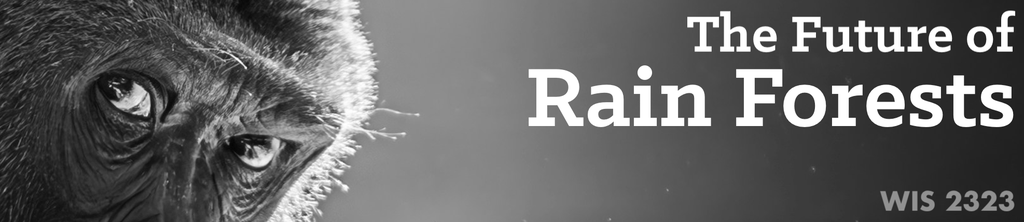

# 1 Course Overview

### Course Sessions

**When:** Tuesdays 3:00-3:50 and Thursdays 3:00-4:55  
**Where:** LIT 0231 (both days)

### Instructor and TA

**Instructor:** Dr. Emilio M. Bruna  
email: embruna@ufl.edu  
phone: (352) 846-0634  
Office: Tropical Ecology & Conservation Lab, 711 Newell Dr.

**TA:** Priyanka Hari Haran  
email: phariharan1@ufl.edu  
Phone: (352) 846-0527  
Office: Tropical Ecology & Conservation Lab, 711 Newell Dr.

### Course Description & Objectives

This course investigates the fundamental issues addressed by scientists studying tropical rain forests, including what gave rise to their remarkable biodiversity, the drivers and consequences of deforestation, why people are fascinated by rain forests, cultural stereotypes about the tropics, and if forest conservation is compatible with socioeconomic development. *By the end of the course students will be able to:*

- Recognize and describe stereotypes about rain forests & their residents
- Analyze rain forest tropes in art, literature, & popular culture
- Discuss & evaluate hypotheses for the origins and maintenance of tropical biodiversity
- Explain & compare human history in rain forests
- Review contemporary threats to rain forests
- Analyze and visualize data on deforestation
- Review and contrast strategies for rain forest conservation & restoration
- Identify rain forests in their daily lives & set personal goals for advancing their conservation
- Produce materials for communicating about rain forests to family and peers

### GenEd and Quest Information

**A minimum grade of C is required for Quest and General Education credit.** Courses intended to satisfy Quest and General Education requirements cannot be taken S-U. *This course fulfills the following Quest and GenEd requirements:*

- Quest 2
- GenEd International
- *Credits:* 3
- *Prerequisites:* None

**This also counts towards a minor or certificate in Latin American Studies.**  
See [www.latam.ufl.edu/academics/undergraduate-programs](https://www.latam.ufl.edu/academics/undergraduate-programs/) for more information.

### Required Course Materials & Supplies Fees

**Students are not required to purchase any textbooks or course materials;** all materials, including readings and videos, will be available on the course Canvas page. However, many of the assigned readings from the *New York Times* and *Washington Post* have dynamic multimedia data visualizations and video that can’t be appreciated in the posted .pdf format. *Students in this class should sign up for free online access to the New York Times* and *Washington Post* by following the instructions at [this UF Libraries Website](https://businesslibrary.uflib.ufl.edu/c.php?g=943928&p=7708734).

**Materials and Supplies Fees**: None.

### Office Hours

**Instructor:** Wednesday & Friday 1:30-3:00 pm or by appointment (in-person & online). Drop by anytime or sign up for a specific time here: https://embruna.youcanbook.me.

**Teaching Assistant:** Tuesday 1:00-2:30 pm or by appointment (in-person & online).

*Location: In-person:* The Tropical Ecology & Conservation Lab is located next to the Rawlings Hall bus stop (711 Newell Drive; to find a map click the “Contact” link at [BrunaLab.org](http://brunalab.org)). *Location - online:* use the zoom link on the course Canvas page. We are online the entire session.

[figure not shown]

# 2 Assignments, Grades, & Attendance

Learning in our class is achieved with an diverse array of methods ranging from data analysis to essays to projects. In most class sessions you will also be working with small groups of students to complete an in-class assignment that reinforces the major themes of the day’s topic. In keeping with the philosophy of the Quest program, this course also has *Experiential Learning and Self-Reflection Components*. For details on the different types of assignments and the Quest Learning Components, see course Canvas page.

### Assignments (1000 points total)

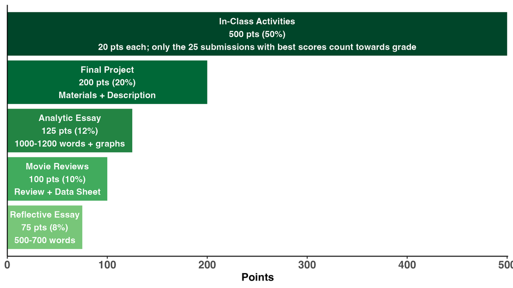

### Grading

**In-class Assignments are due by the following class session.** Late assignments will lose 10 pts.

*Regrades:* Requests for re-evaluation of assignments must be accompanied by an explanation for why you think you deserve additional credit and the number of additional points you think you deserve. The deadline for submission is one week after the work was returned.

*Grade Assignment* (based on % of total points earned): A = 94–100%, A- = 90–93%, B+ = 87–89%, B = 84–86%, B- = 80–83%, C+ = 77–79%, C = 74–76%, C- = 70–73%, D+ = 67–69%, D = 64–66%, D- = 60–63%, E<60

*Grade Points:* For information on how UF assigns grade points, visit: <https://catalog.ufl.edu/UGRD/academic-regulations/grades-grading-policies/

### Attendance & Participation

*Attendance:* Though attendance is not required, many of the sessions we will be completing activities in class that count towards your grade. Most of these can be completed independently, but by doing them in class you will benefit from working collaboratively with the other students.

*Some of the in-class activities can not be completed outside of class time.* If you miss class on one one of these days, that is why the grade for in-class activities is based on a subset of the total activities; you can also elect to make up lost points with extra-credit assignments. *If you need to miss class for any reason, please let me know as soon as possible*. We will make arrangements for you to complete any assignments and go over any material you will be missing. I would much rather you focus on your health, attend your conference, or support friends and family in need than struggle to turn in assignments.

*Participation:* Consistent informed, thoughtful, and considerate class participation is encouraged (and in some cases required). *If you have personal issues that prohibit you from joining freely in class discussion (e.g., shyness, language barriers, medical condition): no problem.* let us know and we will discuss alternative modes of participation.

*Important note regarding class discussions and group work:* We will explore some challenging, important problems and increase our understandings of different perspectives and approaches for addressing them. These conversations may not always be easy; we sometimes will make mistakes in both how we communicate our perspective and what we hear other say. There may be times when we need patience, courage, imagination, and of course mutual respect to engage our texts, classmates, instructors, guests, and our own ideas and experiences. *Disrespectful or disruptive behavior will not be tolerated*. And always remember that as scholars we must employ critical thinking, rely on data, and cite verifiable sources and experts to interrogate all assigned readings and subject matter in this course as a means of determining if we agree with classmates and instructors. No lesson is intended to espouse, promote, advance, inculcate, or compel a particular feeling, perception, viewpoint or belief.

[figure not shown]

# 3 Semester Calendar & Key Dates

[output not shown]

[figure not shown]

# 4 FAQ

|  | How will you send announcements to the class? | Canvas! Check the course Canvas page for announcements and be sure you are recieving Canvas emails and updates. |
| --- | --- | --- |

|  | Class discussions are difficult for me. Will this affect my grade? | No! If there are issues that make engaging in discussions difficult (e.g., shyness, language barriers, a medical condition), let us know and we will find alternative modes of participation. |
| --- | --- | --- |

[output not shown]

# 5 UF Resources for Students

### Health, Safety, & Wellness

Students experiencing crises or personal problems that interfere with their general well-being are encouraged to utilize the university’s counseling resources. The Counseling & Wellness Center provides confidential counseling services at no cost for currently enrolled students. Resources are available on campus for students having personal problems or lacking clear career or academic goals, which interfere with their academic performance. *Visit https://one.uf.edu/whole-gator/discover for resources that are designed to help you thrive physically, mentally, and emotionally at UF.*

- *University Counseling & Wellness Center*, 3190 Radio Road, 352-392-1575. They can provide Counseling Services, Groups and Workshops, Outreach and Consultation, a Self-Help Library, and Wellness Coaching. http://www.counseling.ufl.edu/.
- *U Matter, We Care.* If you or someone you know is in distress, please contact umatter@ufl.edu, 352-392-1575, or visit U Matter, We Care website (www.umatter.ufl.edu/) to refer or report a concern and a team member will reach out to the student in distress.

Call 352-392-1161 for 24/7 information to help you find the care you need, or visit the Student Health Care Center website.

Visit UF Police Department website or call 352-392-1111 (or 9-1-1 for emergencies).

For immediate medical care call 352- 733-0111 or go to the emergency room at 1515 SW Archer Road, Gainesville, FL 32608; Visit the UF Health Emergency Room and Trauma Center website.

The Hitchcock Pantry can provide food and toiletries for students experi- encing food insecurity. https://pantry.fieldandfork.ufl.edu/.

### Academic Services

Contact the UF Computing Help Desk: (352) 392-4357 or helpdesk@ufl.edu.

Help brainstorming, formatting, and writing papers. Daytime (9:30am-3:30pm): 2215 Turlington Hall, 352-846-1138. Evening (5:00pm-7:00pm): 1545 W University Avenue (Library West, Rm. 339).

Reitz Union Ste 1300, (352) 392-1601. Career assistance & counseling services.

Various ways to receive assistance with respect to using the libraries or finding resources. Call 866-281-6309 or email ask@ufl.libanswers.com for more information.

1317 Turlington Hall, Call (352) 392-2010 or to make a private appointment: 352- 392-6420. Email contact: teaching-center@ufl.edu. General study skills and tutoring.

http://studentsuccess.ufl.edu.

[Office of the Ombuds](https://ombuds.ufl.edu/); Visit the [Complaint Portal webpage](https://ombuds.ufl.edu/complaint-portal/) for more information.

View the Student Complaint Procedure webpage for more information.

Visit https://studentsuccess.ufl.edu/ for resources that support your success as a UF student.

# 6 UF Policies

[output not shown]

[output not shown]

[output not shown]

[output not shown]

# 7 Weekly Reading & Viewing

**Please review the assigned material *before* class. *All items are posted on the Canvas site. Topics & readings are subject to change based on current events; changes will be announced via Canvas.***

## Week 1

### 1-2: Course Introduction

1. *Read:* None

## Week 2

### 2-1: Historical Narratives

> *Goal: To introduce and discuss how historical narratives by the first Europeans to visit the tropics have shaped contemporary perceptions of tropical rain forests and the colonial roots of tropical biology*
1. *Read:* Excerpts from Historical Narratives [6 pages: [link](https://ids2935.netlify.app/uploads/historical_narratives.pdf)]

### 2-2 Historical Narratives

> *Goal: To introduce and discuss how historical narratives by the first Europeans to visit the tropics have shaped contemporary perceptions of tropical rain forests and the colonial roots of tropical biology*
1. *Read:* Excerpts from Historical Narratives [6 pages: [link](https://ids2935.netlify.app/uploads/historical_narratives.pdf)]

## Week 3

### 3-1 Historical Narratives (cont.); Rain Forest Imagery in Art & Literature

1. *Read:* Excerpts from Literature/Poetry [link](https://ids2935.netlify.app/03_trf_culture/lit_poetry.pdf) (5 pages)
2. *Review:* Images of artwork [link] (4 pages)

### 3-2 The Rain Forest in Pop Culture (pt 1)

> *Goal: To compare the use and presentation of rain forest images by the private sector and in different forms of popular culture, including the film and music industries, and to evaluate how these depictions influence perceptions of tropical countries & people.*
1. *Read:* None

## Week 4

### 4-1 The Rain Forest in Pop Culture (pt 2)

1. *Read:* Jolly, Priscilla. 2021. ‘Godzilla vs. Kong’: Monster movies evoke adventure but also ‘dangers’ of tropics. The Conversation. [[link to read online](https://theconversation.com/godzilla-vs-kong-monster-movies-evoke-adventure-but-also-dangers-of-tropics-158105)] (4 pages)
2. *Read:* Rose, Steve. 2016. “From Tarzan to Avatar: the problem with ‘the white man in the jungle’”. The Guardian [[link to read online](https://www.theguardian.com/film/2016/jul/06/why-the-white-man-in-the-jungle-film-wont-die)] (newspaper story, 5-10 min. read)

### 4-2 What is a Rain Forest?

> *Goal: To learn the different ways biologists define the “tropics” and how the structure and dynamics of tropical rain forests differ from those of forests in other parts of the world.*
1. *Watch:* Why Does Earth Have Deserts? [[link to video](https://www.youtube.com/watch?v=T6Us1sPXBfA)]; 2 min long]
2. *Watch:* Emma Napper, British Broadcasting Corporation, ZDF, T., Tencent, & France Télévisions (Producers), & Napper, E. (Director). (2016). Jungles. [Video/DVD] BBC Worldwide. Retrieved from https://video.alexanderstreet.com/watch/Jungles-2

## Week 5

### 5-1 What else is a rain forest?

> *Goal: To understand the geological history of tropical rain forests, how climate, fire, and geological history drive the tipping point between forests and savannas, and how this biogeographic, geological, and climatic history shaped the evolution of tropical plants and animals*
1. *Read:* “Ch. 4: Finding animals in the rainforest” from Kricher, J.C. (2017). The new neotropical companion. In The New Neotropical Companion. Princeton Univ. Press (13 pp)

### 5-2: Patterns of Biodiversity 1

> *Goal: An overview of (a) diversity gradients and (b) local patterns of species richness and abundance in tropical forests and (c) how these differ from the temperate zone*
1. *Read:* We will be using iNaturalist in class. You can familiarize yourself in advance by reviewing the iNaturalist website https://www.inaturalist.org/ after reading this: Matthew Earl Boone and Mathieu Basille. Using iNaturalist to contribute your nature observations to science (UF EDIS Document WEC413) [link]
2. *Watch:* Why Are There So Many Species Near the Equator? [[link to video](https://www.youtube.com/watch?v=IrbKix96_k0), 4:50 long]

## Week 6

### 6-1: Patterns of Biodiversity 2

1. *Read:* None

### 6-2: The Origins of Tropical Biodiversity, Disturbance, & The Paradox of Luxuriance

> *Goal: To observe and catalog the diversity of plant and animal life forms that can be found in rain forests and review hypothesized mechanisms for the origins of tropical diversity.*
1. *Watch:* Ingrid Kvale, & British Broadcasting Corporation (Producers), & Kvale, I. (Director). (2021). Borneo: Sacred Forest. [Video/DVD] BBC Worldwide. Retrieved from https://video.alexanderstreet.com/watch/borneo-sacred-forest

> *Goal: To understand how interspecific interactions led to the (co)evolution and diversification of tropical biodiversity*
1. *Read:* “Ch. 3: The Realm of Plants” from Kricher, J. C. (2017). The new neotropical companion. In The New Neotropical Companion. Princeton University Press. (18 pp).
2. *Watch:* An introduction to Army Ants: [[link to video](https://www.youtube.com/watch?v=p16g5IVCdeE), 9 min long].
3. *Watch:* See also this Army Ant Video by the BBC: [[link to video](https://www.youtube.com/watch?v=JsfiUR0ZzLw), 3 min long].
4. *Watch:* A closer look at the Army Ant Birds: [[link to video](https://www.youtube.com/watch?v=SQPcIYV_vKM), 14 min long].

> *Goal: To understand how such a productive biome can be built on such low-quality soils, and explore the implications of this “Paradox of Luxuriance”.*
1. *Read:* Langewiesche, William. 2022. “The War for the Rainforest.” NY Times. [[read online](https://www.nytimes.com/2022/03/16/magazine/amazon-rainforest-ituna-itata.html)]

## Week 7

### 7-1 FLMNH - Butterfly Rain Forest

> *Goal: To review the biotic and abiotic mechanisms in tropical rain forests that permit the coexistence of so many species.*
1. *Watch:* Is this the biggest flower in the world? “BBC Earth: Corpse Flower Stinks of Death” [[link to video](https://www.youtube.com/watch?v=YxIpl38rsMo), 4 min long].
2. *Watch:* A slightly less dramatic video in which you can get a better idea of the flower’s size: [[here](https://www.youtube.com/watch?v=0cGRujABwuQ), 3 min long]
3. *Watch:* Maybe this is the biggest flower: The Titan arum [[link to video](https://www.youtube.com/watch?v=5Jg-GlCXpEI), 2 min long]

### 7-2 Humans are Part of Rain Forests

> *Goal: To understand the history of human occupation of rain forests including the contemporary demographic transition from rural to urban occupation; to review the different ways in which humans have historically modified rain forests and how this has shaped current rain forest biodiversity.*
1. *Watch:* Kristine Allington, Michael Amundson, Linithd Aparicio, & Caitlin Saks (Producers), & Townsley, G. (Director). (2023). Ancient Builders of the Amazon. [Video/DVD] Public Broadcasting Service. Retrieved from https://video.alexanderstreet.com/watch/ancient-builders-of-the-amazon

## Week 8

### 8-1 JUNGLE FILM FESTIVAL

1. *Read:* 1-2 readings TBD based on movie chosen.

### 8-2 How much tropical rain forest is there?

> *Goal: To learn how forest cover is defined and estimated and how it varies globally
1. *Read:* Louis Lucero II. New Interactive Tool Helps Track Earth’s Forests [[NYTimes](https://www.nytimes.com/2013/11/15/science/earth/new-interactive-tool-helps-track-earths-forests.html), 10 min read].

## Week 9

### 9-1 How much tropical rain forest have we lost?

> *Goal: To use forest cover data to estimate rates of tropical forest loss over time*
1. *Read:* Manuela Andreoni 2023 “Despite Global Pledges, Tree Loss Is Up Sharply in Tropical Forests” [[read online](https://www.nytimes.com/2023/06/27/climate/trees-tropical-forests-deforestation.html), 10 min read]
2. *Read:* Nolen, Stephanie (Reporting) with Elkaim, Aaron Vincent (Photographs). 2018. “Inside the Amazon’s Deforestation Crisis”. The Globe and Mail. [[read online](https://www.theglobeandmail.com/news/world/amazon-rainforest-deforestation-crisis/article37722932/), 20 min read].

### 9-2 Drivers & Consequences of Deforestation: Mining, Timber, Fire, Infrastructure

> *Goal: Learn (a) how deforestation and other human activities alter the structure & functioning of rain forests, and (b) compare how these drivers differ between the African, American, and Asian tropics.*
1. *Read:* Andreoni, Manuela, Blacki Migliozzi, Pablo Robles and Denise Lu. Photographs by Victor Moriyama. 2022. “The Illegal Airstrips Bringing Toxic Mining to Brazil’s Indigenous Land”. NY Times. [[read online](https://www.nytimes.com/interactive/2022/08/02/world/americas/brazil-airstrips-illegal-mining.html), 15 min read].
2. *Read:* Searcey, Dionne (reporting) and Gilbertson, Ashley (photographs). 2022 “Raft by Raft, a Rainforest Loses Its Trees” NY Times. [[read online](https://www.nytimes.com/interactive/2022/06/14/climate/congo-rainforest-logging.html), 10 min read].

## Week 10

### 10-1 Drivers & Consequences of Deforestation: Agriculture

> *Goal: Continue learning (a) how deforestation and other human activities alter the structure & functioning of rain forests, and (b) compare how these drivers differ between the African, American, and Asian tropics.*
1. *Read:* Devouring the Rain Forest. Washington Post. [[read online](https://www.washingtonpost.com/world/interactive/2022/amazon-beef-deforestation-brazil/), 20 min read].
2. *Read:* Robles, Pablo, Anuradha Raghu, Adam Majendie and Jin Wu 2021. “The World’s Addiction to Palm Oil Is Only Getting Worse”. Bloomberg News. [[read online](https://www.bloomberg.com/graphics/2021-palm-oil-deforestation-climate-change/), 10 min read].
3. *Read:* Mason, Margie & McDowell, Robin. 2020. “Palm oil labor abuses linked to world’s top brands, banks”. Associated Press. [[read online](https://apnews.com/article/virus-outbreak-only-on-ap-indonesia-financial-markets-malaysia-7b634596270cc6aa7578a062a30423bb), 10 min read].

### 10-2 Climate Change and Tropical Forests

> *Goal: Climate change and Tropical Forests To understand the relationship between tropical forests, deforestation, and the global climate cycle.*
1. *Watch:* BBC News: Amazon rainforest: ‘Once it’s gone, it’s gone forever’ (interview with Erika Berenguer). [[link to video](https://www.youtube.com/watch?v=TigV80hwebg), 3 min long].
2. *Read:* Pearce, Fred. 2018. “Rivers in the Sky: How Deforestation Is Affecting Global Water Cycles.” Yale360. [[read online](https://e360.yale.edu/features/how-deforestation-affecting-global-water-cycles-climate-change), 10 min read].

## Week 11

### 11-1 Adressing Climate Change

1. *Read:* Serkez, Yaryna. 2020. Every Place Under Threat. NY Times. [[read online](https://www.nytimes.com/interactive/2020/10/02/opinion/amazon-under-threat.html), 10 min read].
2. *Read:* learn about the EN-ROADS simulator we will be using in class at this [[link to website](https://www.climateinteractive.org/en-roads/), 15 min read]. You can even start experimenting with it here: [[link to site](https://en-roads.climateinteractive.org/scenario.html?v=22.8.0)].

### 11-2 Consumer Choices

> *Goal: To understand how global production and chains and consumer demand in Europe and North America influence patterns of deforestation in tropical countries.*
1. *Read:* Carodenuto, Sophia. 2021. “Chocolate fix: How the cocoa industry could end deforestation in West Africa”. The Conversation. [[read online](https://theconversation.com/chocolate-fix-how-the-cocoa-industry-could-end-deforestation-in-west-africa-161953), 10 min read].
2. *Read:* Lawal,Shola. 2020. “Our Endless Appetite For Chocolate Has Bitter Environmental Consequences” Huffington Post. [[read online](https://tinyurl.com/y6curgmn), 10 min read].
3. *Read:* Hunt, Chris and Premathilake, Rathnasiri. 2018. “Prehistoric people started to spread domesticated bananas across the world 6,000 years ago.” The Conversation. [[read online](https://theconversation.com/prehistoric-people-started-to-spread-domesticated-bananas-across-the-world-6-000-years-ago-99547), 5 min].
4. *Read:* Optional: Mufson, Steven and Georges, Salwan. 2019. “The trouble with chocolate” Washington Post [[read online](https://www.washingtonpost.com/graphics/2019/national/climate-environment/mars-chocolate-deforestation-climate-change-west-africa/) to see the amazing maps, pictures, and data visualizations.
5. *Read:* Optional: Williams, Wyatt. 2021. “How Your Cup of Coffee Is Clearing the Jungle”. NY Times. [[read online](https://www.nytimes.com/2021/08/11/magazine/indonesia-rainforest-coffee.html)] Longer, but really gripping and the article includes a link to an audio version if you prefer to listen to it.

## Week 12

### 12-1 DURIAN FEST 2022

> *Goal: To learn about the global market in tropical fruit crops and the economic impact of tropical fruit production in Florida.*
1. *Read:* Weintraub, Karen. 2019. “They’re Smelly and Spiky, and They Need Bats to Pollinate Them”. NY Times. [[read online](https://www.nytimes.com/2019/12/04/science/bats-durians-indonesia.html), 5 min read].
2. *Read:* Wharton, Rachel. 2020. How the Tip of Florida Became a Tropical-Fruit Paradise. Atlas Obscura. [[read online](https://www.atlasobscura.com/articles/tropical-fruit-farms-in-united-states), 5 min read].
3. *Read:* Frías, Carlos. 2022. “Oddly colored and somewhat phallic: How Miami’s rare tropical fruit went TikTok viral.” Miami Herald. [[read online](https://www.miamiherald.com/miami-com/restaurants/article263608093.html#storylink=cpyhttps://www.miamiherald.com/miami-com/restaurants/article263608093.html), 5 min].

### 12-2 International Frameworks

> *Goal: To learn about the major local, national, and multi-national approaches to reducing deforestation by comparing their efficacy and socioeconomic impacts. REDD and Payment for Ecosystem Services.*
1. *Read:* UN-REDD Programme: An introduction to REDD+ [link].

> Note: this is a slide deck designed to introduce the REDD+ framework to a general audience. The content is exceptional, but don’t just read the material – think about how it is being presented (graphics, etc.) and if it effectively communicates their message. I’ve asked you do this not just to prepare for today’s lesson, but because it will be useful for your Final Project (TL;dr…the presentation is awful: busy slides, too much text, overly complicated graphics…we’ll talk about how it could be improved).

## Week 13

### 13-1 Local Initiatives, Empowered Communities, Activism, & Philanthropy

> *Goal: To learn about how local communities are engaged in rain forest conservation and sustainable development efforts in the tropics and beyond.*
1. *Read:* Ruth Maclean (reporting, writing), Caleb Kabanda (reporting), and Nanna Heitmann (photography). 2022. “What do the protectors of Congo’s peatlands get in return?” NY Times. [[read online](https://www.nytimes.com/interactive/2022/02/21/headway/peatlands-congo-climate-change.html), 10 min read].
2. *Read:* Kimbrough, L. 2021. “How settlers, scientists, and a women-led industry saved Brazil’s rarest primate”. Mongabay.com [[read online](https://news.mongabay.com/2021/05/how-settlers-scientists-and-a-women-led-industry-saved-brazils-rarest-primate/), 10 min read].
3. *Read:* Don’t underestimate what one person can do on their own: “BBC World Service: The man who grew his own rainforest” [[link to video](https://www.youtube.com/watch?v=AngaeIf78AQ), 5 min long] (keep an eye out for the Euglossine bees we learned about earlier in the semester…you can see them collecting scented oil from flowers at 2:04).
4. *Read:* Arellano, Astrid and Sierra Praeli, Yvette. 2022. “A look at violence and conflict over Indigenous lands in nine Latin American countries”. Mongabay.com . [[read online](https://news.mongabay.com/2022/05/a-look-at-violence-and-conflict-over-indigenous-lands-in-nine-latin-american-countries/?utm_medium=Social&utm_source=Twitter#Echobox=1654027741-1), 20 min read].

### 13-2 Protected Areas

> *Goal: To learn about different global categories of protected areas, the importance of protected areas in the tropics for conserving forest, and how the threats to protected areas vary regionally and globally.*
1. *Read:* Dasgupta, Shreya (with research by Annika Schlemm & Zuzana Burivalova). 2017. “Do protected areas work in the tropics?” Mongabay.com. [[read online](https://news.mongabay.com/2017/12/do-protected-areas-work-in-the-tropics/), 25 min read].

## Week 14

### 14-1 Project Work Day.

1. *Read:* None

### 14-2 No class: Thanksgiving Holiday

1. *Read:* None

## Week 15

### 15-1 Forest Restoration & Regeneration

> *Goal: To learn the difference between passive regeneration and active restoration and assess evidence for whether they can be used to reverse the effects of deforestation*
1. *Read:* Medici, Patricia. 2015 TED Fellows Talk. “The coolest animal you know nothing about…and how we can save it”. [[link to video](https://www.ted.com/talks/patricia_medici_the_coolest_animal_you_know_nothing_about_and_how_we_can_save_it#t-694653), 11:20 min long].
2. *Read:* “Do tapirs defecate in the woods?” 2019. The Economist [[read online](https://www.economist.com/science-and-technology/2019/04/17/do-tapirs-defecate-in-the-woods), 5 min read].
3. *Read:* Come prepared to make some money: we’re looking into the economic benefits of setting aside land (or not) for conservation. To prepare, look this document over before class: [[link](https://www.tandfonline.com/doi/full/10.1080/00220485.2016.1146098), 10-15 min read].

### 15-2 Tropical Rain Forests and Global Health

> *Goal: To learn about the relationship between deforestation and the emergence and spread of tropical diseases like Zika and Malaria from the tropics to other regions of the globe*.
1. *Read:* Lavinas Picq, Manuela 2020. “Spreading Faith, and Disease”. NY Times. [[read online](https://www.nytimes.com/2020/10/02/opinion/amazon-missionaries-tribes-disease.html), 15 min read].
2. *Read:* Vittor, Amy, Gabriel Zorello Laporta, and Maria Anice Mureb Sallum. 2020. How deforestation helps deadly viruses jump from animals to humans. The Conversation. [[read online](https://theconversation.com/how-deforestation-helps-deadly-viruses-jump-from-animals-to-humans-139645), 15 min read].
3. *Read:* Kuchipudi, Suresh V. 2020. Why so many epidemics originate in Asia and Africa – and why we can expect more. The Conversation. [[read online](https://theconversation.com/why-so-many-epidemics-originate-in-asia-and-africa-and-why-we-can-expect-more-131657), 10 min].

## Week 16

### 16-2 Rain Forest Headlines / What will you do?

> *Goal: To learn how journalists based in different countries or different global audiences chose and cover stories about rain forests and deal with the risks of covering this beat*.
1. *Read:* Nicas, Jack (reporting) and Moriyama,Victor (Photos, Video). 2022. Inside the Amazon Journey That Left a Journalist and an Activist Dead. NY Times. [[read online](https://www.nytimes.com/interactive/2022/07/11/world/americas/amazon-murder-dom-phillips-bruno-pereira.html?smid=tw-nytimes&smtyp=cur), 15 min read]
2. *Read:* Jennifer Weeks. Ending Amazon deforestation: 4 essential reads about the future of the world’s largest rainforest. The Conversation [link] (4 pages)

# 8 Student Learning Objectives